# Final Paper

2025-09-29

## Executive Summary

- This project investigates the critical relationship between structural design choices in aerospace engineering and their measurable impact on operational performance.
- Using a curated dataset of 300 aircraft design records, we explore how material type, wing span, fuselage length, load distribution, vibration damping, and weight efficiency interact to influence durability, altitude capability, and operational life.
- Our central research question is: How do material and geometry choices influence the efficiency, stability, and longevity of aerospace structures?

## Executive Summary

- This study contributes dual value: it reinforces engineering intuition (e.g., the trade-off between weight efficiency and durability across materials), while also demonstrating how modern analytics can support data-driven decision-making in aerospace design.
- By the end of the analysis, we aim to deliver not only statistical insights but also a narrative that illustrates the delicate balance of wings, weight, and material strength that underpins safe and efficient flight.

## Data Preparation

```
## # A tibble: 6 × 22
##   `Material Type` `E (GPa)`     ν `ρ (kg/m³)` `Tensile Strength (MPa)`
##   <chr>               <dbl> <dbl>       <dbl>                    <dbl>
## 1 Aluminum            186.  0.308       2731.                    1424.
## 2 Titanium             59.9 0.309       1970.                     467.
## 3 Carbon Fiber        136.  0.347       3659.                     961.
## 4 Aluminum            103.  0.311       3378.                    1432.
## 5 Aluminum            137.  0.308       1860.                    1448.
## 6 Aluminum            143.  0.346       3835.                     289.
## # ℹ 17 more variables: `Young’s Modulus` <dbl>, `Altitude (m)` <dbl>,
## #   `Temperature (°C)` <dbl>, `Pressure (Pa)` <dbl>,
## #   `Operational Life (years)` <dbl>, `Wing Span (m)` <dbl>,
## #   `Fuselage Length (m)` <dbl>, `Structural Thickness (mm)` <dbl>,
## #   `Structural Shape` <chr>, `Load Distribution` <chr>,
## #   `Vibration Damping` <chr>, `Computational Time` <chr>,
## #   `Weight Efficiency` <chr>, Durability <chr>, …
```

## Feature engineering

- wing to fuselage — this ratio is an interpretable engineering feature.
- wing span relative to fuselage length can influence structural loads, aerodynamic efficiency, and hence weight trade-offs.
- We also create quantile bins to use in grouped displays.

## Visualization - 1

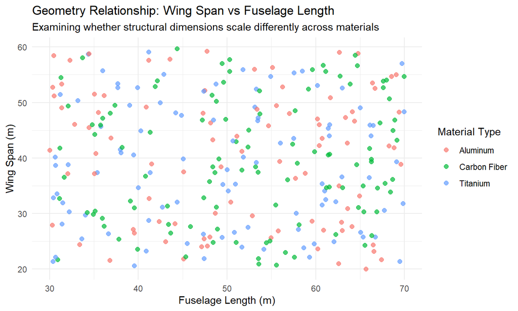

## Visualization - 2

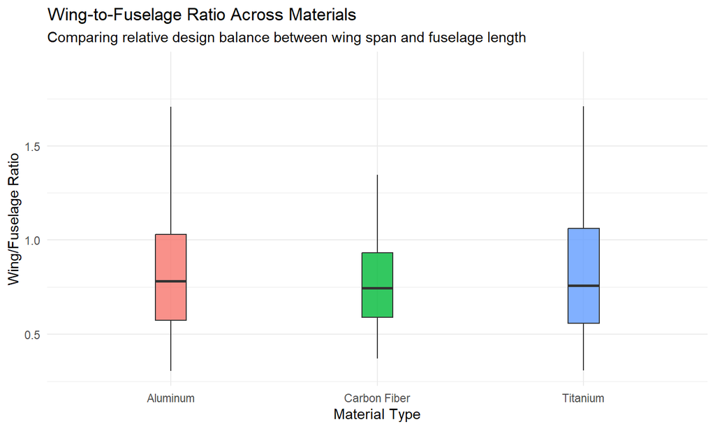

## Visualization - 3

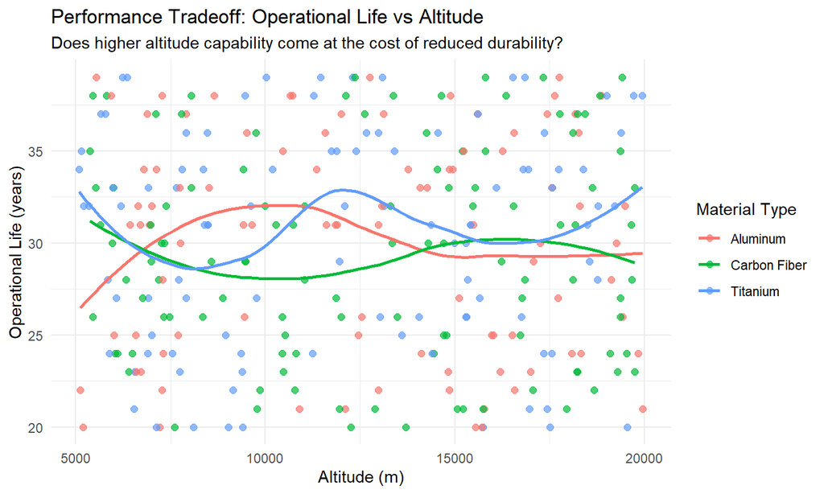

## Visualization - 4:

[figure not shown]

## Visualization - 5

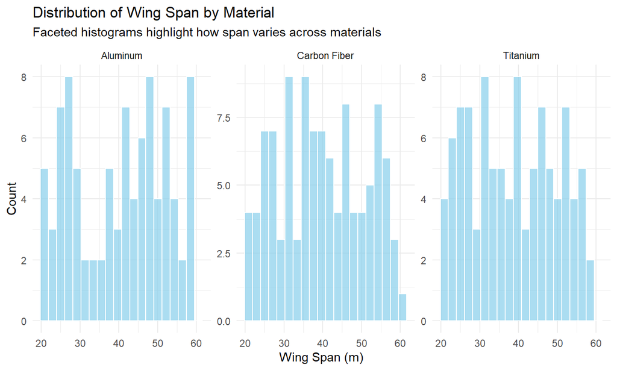

## Visualization - 6

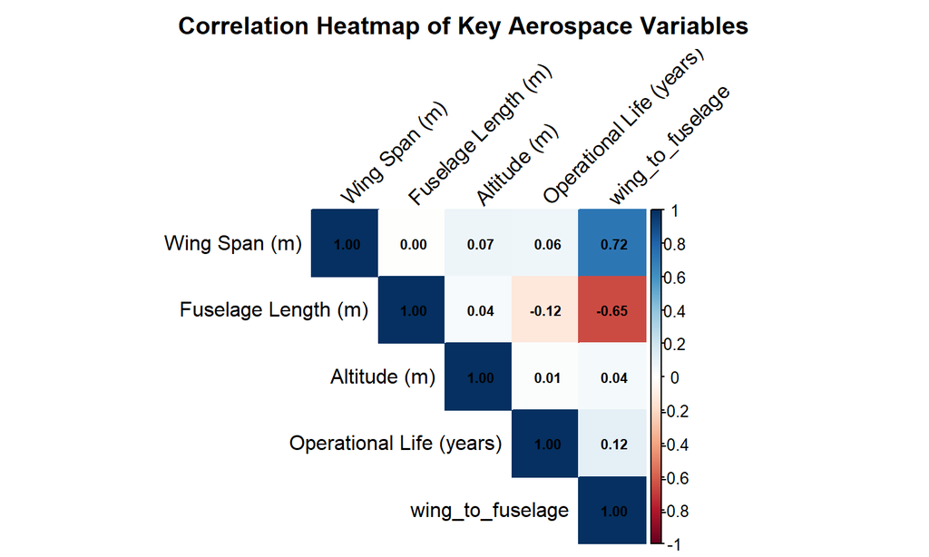

## Correlational Heatmap

Strong positive correlation between Wing Span and the Wing-to-Fuselage ratio (0.72). - Longer wings relative to fuselage strongly increase this ratio, reinforcing geometric design logic.

Altitude shows only weak correlations with other variables. - Suggests altitude capability depends more on aerodynamic efficiency and material type than raw dimensions.

## ANOVA Test

```
##                  Df Sum Sq Mean Sq F value Pr(>F)
## `Material Type`   2    129   64.27   0.508  0.602
## Residuals       297  37537  126.39
```

```
##                  Df Sum Sq Mean Sq F value Pr(>F)
## `Material Type`   2    380   189.9   1.315   0.27
## Residuals       297  42893   144.4
```

```
##                  Df Sum Sq Mean Sq F value Pr(>F)
## `Material Type`   2     55   27.51   0.819  0.442
## Residuals       297   9983   33.61
```

## ANOVA Results

- Even though the ANOVA tests suggest no statistically significant differences, this doesn’t mean materials are irrelevant.
- In aerospace engineering, practical effects (like composites enabling lighter but stronger designs) may not always show up as statistically significant when averaged across many designs.
- This highlights that geometry + design philosophy may have a bigger influence than just material category.

## Chi-Square Test

```
##
##                Low Medium High
##   Aluminum      27     34   31
##   Carbon Fiber  39     33   37
##   Titanium      33     41   25
```

```
##
##  Pearson's Chi-squared test
##
## data:  chisq_table
## X-squared = 4.0277, df = 4, p-value = 0.4023
```

## Chi-Square Test: Material Type vs Durability

- Null Hypothesis (H₀): Durability distribution is independent of material type.
- Test result: χ²(4) = 4.03, p = 0.40 → Fail to reject H₀.
- Interpretation: No statistically significant association between material type and durability.

## Interpretation:

- Durability is influenced by multiple interacting factors — not just the material used.
- Load distribution, geometry (wing-to-fuselage ratio), and vibration damping may have stronger effects than material type alone.
- This aligns with aerospace engineering practice: material provides potential, but design execution defines actual durability.

## Regression Analysis

```
##
## Call:
## lm(formula = `Operational Life (years)` ~ `Wing Span (m)` + `Fuselage Length (m)` +
##     `Altitude (m)` + `Material Type`, data = temp)
##
## Residuals:
##      Min       1Q   Median       3Q      Max
## -11.7296  -4.9985   0.7432   4.8855  10.1525
##
## Coefficients:
##                               Estimate Std. Error t value Pr(>|t|)
## (Intercept)                  3.121e+01  2.117e+00  14.741   <2e-16 ***
## `Wing Span (m)`              3.352e-02  2.988e-02   1.122   0.2629
## `Fuselage Length (m)`       -5.562e-02  2.790e-02  -1.994   0.0471 *
## `Altitude (m)`               2.127e-05  7.386e-05   0.288   0.7735
## `Material Type`Carbon Fiber -5.539e-01  8.185e-01  -0.677   0.4992
## `Material Type`Titanium      3.581e-01  8.396e-01   0.427   0.6700
## ---
## Signif. codes:  0 '***' 0.001 '**' 0.01 '*' 0.05 '.' 0.1 ' ' 1
##
## Residual standard error: 5.775 on 294 degrees of freedom
## Multiple R-squared:  0.02327,    Adjusted R-squared:  0.006656
## F-statistic: 1.401 on 5 and 294 DF,  p-value: 0.2239
```

## Interpretation

- Structural variables (span, fuselage length, altitude, materials) do not strongly predict operational life.
- The only marginally significant factor is fuselage length — longer fuselages slightly reduce lifespan.
- This suggests that operational life is influenced more by other factors (e.g., maintenance cycles, environmental stressors, flight hours) that are not in the dataset.
- Aerodynamic scaling (span/fuselage) plays a role in load distribution, but durability over decades depends more on real-world operations and fatigue cycles than just static geometry.
- Material differences may matter more when combined with environmental/maintenance variables.

## Conclusion

- **Regression analysis** revealed that fuselage length has a small but significant negative effect on operational life, while wing span, altitude, and material type were not strong predictors.
- Taken together, the findings suggest that **structural design choices matter**, but **real-world operational life is shaped by broader factors** (maintenance, fatigue cycles, and environmental stresses) not captured in this dataset.

## Future Work

- **Integrate operational data:** Flight hours, maintenance records, and environmental load histories to better model durability.
- **Expand statistical models:** Explore interaction effects (e.g., material × load distribution) and non-linear patterns.
- **Apply machine learning:** Use decision trees or random forests to highlight hidden factor importance beyond simple regression.

## Future Work

- **Engineering interpretation:** Link data insights more explicitly with physical stress/strain models to balance analytical results with aeronautical design principles.
- Overall, this study illustrates the **value of data-driven analytics in aerospace design** — not to replace engineering judgment, but to **complement and validate it with evidence-based insights**.